# Spatial Machine Learning with mlr3

- Show All Code
- Hide All Code
- View Source

Author

Marvin Ludwig

Published

Last Updated: March, 2025

## 1 Aims of this post

This post aims to give a minimal example on how to use **mlr3** for a spatial prediction task. We want to get from measurements of temperature at specific locations in Spain to a spatially continuous map of temperature for all of Spain.

Such a spatial prediction task is often done by applying machine learning algorithms that are not necessarily developed for spatial tasks specifically and hence do not consider problems we might encounter in the spatial world, e.g., spatial autocorrelation or map extrapolation. In the last decade, a lot of methodological developments were made by various research groups to consider and deal with such specialties of spatial mapping. Many of which found their way in software packages such as **mlr3**.

## 2 Setup

**Hide the code**

```r
install.packages("mlr3verse")
install.packages("mlr3spatiotempcv")
install.packages("sf")
install.packages("terra")
```

**Hide the code**

```r
library(sf)
library(terra)
```

### 2.1 Casestudy data

**Hide the code**

```r
covariates <- terra::rast("https://github.com/LOEK-RS/FOSSGIS2025-examples/raw/refs/heads/main/data/predictors.tif")
temperature <- sf::read_sf("https://github.com/LOEK-RS/FOSSGIS2025-examples/raw/refs/heads/main/data/temp_train.gpkg")

spain <- sf::read_sf("https://github.com/LOEK-RS/FOSSGIS2025-examples/raw/refs/heads/main/data/spain.gpkg") |>
    st_cast("POLYGON") |>
    st_transform(st_crs(temperature))

temperature <- terra::extract(covariates, temperature, bind = TRUE) |>
    sf::st_as_sf()

# the sf object cannot contain a column named "X" or "Y". Otherwise the task creation will fail because "Assertion on 'data' failed: Must have unique colnames"
temperature$X <- NULL
temperature$Y <- NULL
```

Some words about the terminology that is specific to the example data:

- `spain` is the region outline - for visualization purposes and kNNDM setup
- `covariates` are the spatially explicit data data to predict on (to prevent wording confusions with the predict function or the prediction)
- `temperature` are the measured temperature data (i.e. the response variable, i.e., the ground truth) along with the covariates at the measurement location

### 2.2 Official Documentation

The best general introduction to **mlr3** is probably the official **mlr3** book which you can access for free here: https://mlr3book.mlr-org.com/. The homepage https://mlr-org.com/ also gives a very detailed overview of all the associated packages an current developments.  
The individual packages also have their own documentation pages, where you will find more specific topics. The “spatial” packages are the following:

- `mlr3spatial` implements support for spatial data types in R – https://mlr3spatial.mlr-org.com/
- `mlr3spatiotemporalcv` implements spatial cross-validation methods in the workflow – https://mlr3spatiotempcv.mlr-org.com/articles/mlr3spatiotempcv.html – and also uses the `mlr3spatial` package for the spatial data types handling

**Hide the code**

```r
library(mlr3verse)
library(mlr3spatiotempcv)
library(mlr3viz)
```

**mlr3** functions can be very verbose. For this blog post, I turned off messages for a less overwhelming tutorial.

**Hide the code**

```r
lgr::get_logger("mlr3")$set_threshold("warn")
lgr::get_logger("bbotk")$set_threshold("warn")
```

## 3 Getting started with mlr3

First of all, **mlr3** uses `R6` classes and therefor an object-oriented design paradigm. This might be not intuitive for a lot of R users and more in line with something like scikit-learn of Python. In general, with `R6` classes you define an object first, and this object contains all the methods and parameters you can access.

The `R6` class in R has a significant drawback when it comes to RStudio’s convenience features. For example, it does not provide in-line popup help for available parameters in a model. This means you must manually look up the parameters, e.g., needed for the `ranger()` function.”

Let’s define a minimum spatial prediction task example with **mlr3** classes:

**mlr3** uses its own terminology. You have to know a lot of specific terms in order to comfortably use the functions. I try to use the **mlr3** terminology here and give some alternative terms in parenthesis.

### 3.1 Task

The `task` defines general information about the data we have at hand. From our point observations we create the task and define what column the target (response / dependent) variable is, what column the geometry (coordinates) is and whether we want to use the coordinates as features (predictors). In this example, we also split the data in our task into a training and a test partition.

**Hide the code**

```r
task_spain <- mlr3spatial::as_task_regr_st(
    temperature,
    target = "temp",
    coordinate_names = "geometry",
    coords_as_features = TRUE,
    crs = st_crs(temperature)
)

train_test_split <- mlr3::partition(task_spain, ratio = 0.7)
```

**`st_drop_geometry()`**

In **caret**, if we want to use spatial data, we have to specifically exclude the geometry column of the `sf` object. We lose the spatial information in the process of model training and prediction. However, this information can be critical, e.g., if we want to use `CAST::errorprofiles()` or `CAST::knncv()`. In **mlr3** we can keep the geometry and can also directly define whether we want to use the coordinates as predictors.

### 3.2 Learner

The `learner` is the model type or algorithm we want to use with all its necessary or optional parameters. Here I define a Random Forest regression method from the **ranger** package with 100 decision trees and an `mtry` of 4.

**Hide the code**

```r
rfmodel <- mlr3::lrn("regr.ranger", num.trees = 100, mtry = 4)
```

### 3.3 Measure

In order to evaluate the a score (model performance), e.g., from the previously defined test data partition, we need to define a `measure`. Here I use the Root Mean Squared Error (RMSE).

**Hide the code**

```r
measure_rmse <- mlr3::msr("regr.rmse")
```

## 4 Training, Validation and Prediction

We now have everything defined to actually do something. To train the model we can use the `train` method from out defined learner. And we have to tell the `train` method on what to actually fit the model – in this case the data in `task_spain`, but only the subset we sampled as training data.

**Hide the code**

```r
rfmodel$train(task_spain, row_ids = train_test_split$train)
rfmodel$model
```

```
Ranger result

Call:
 ranger::ranger(dependent.variable.name = task$target_names, data = task$data(),      case.weights = task$weights$weight, mtry = 4L, num.threads = 1L,      num.trees = 100L)

Type:                             Regression
Number of trees:                  100
Sample size:                      136
Number of independent variables:  22
Mtry:                             4
Target node size:                 5
Variable importance mode:         none
Splitrule:                        variance
OOB prediction error (MSE):       1.040724
R squared (OOB):                  0.8595686
```

To test how well out model performs now on unseen data, we use the `predict` method of our fitted learner. Again, we tell the `predict` method on what data to predict. We can then calculate the `score` of this test prediction, i.e., the RMSE we defined earlier as out measure.

**Hide the code**

```r
test_prediction <- rfmodel$predict(task_spain, row_ids = train_test_split$test)
test_prediction$score(measure_rmse)
```

```
regr.rmse
 1.016704
```

**Hide the code**

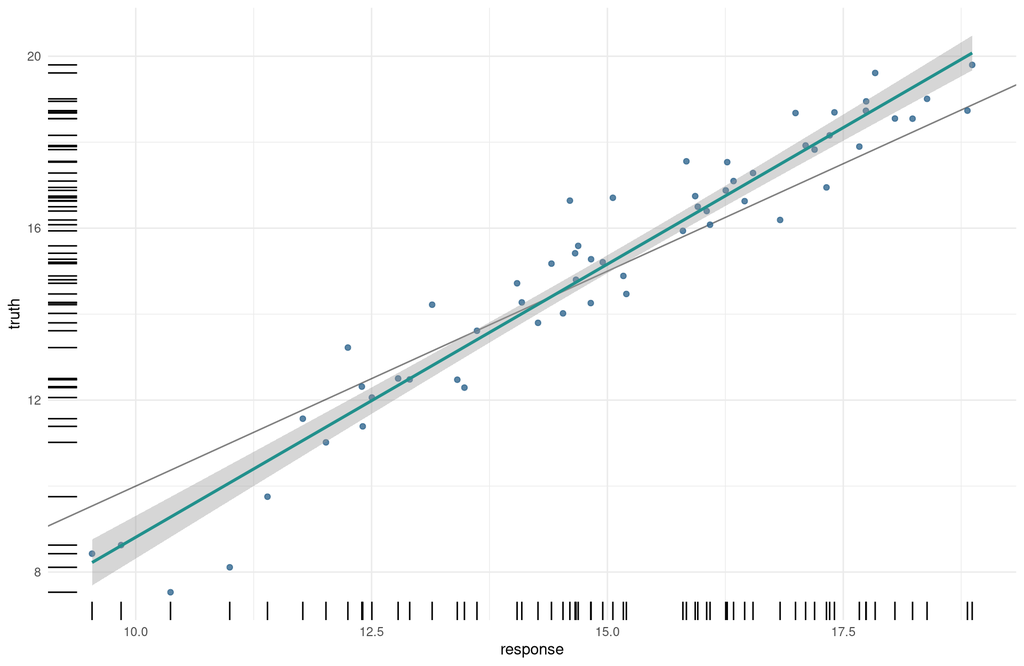

```r
plot(test_prediction)
```

Finally, we can also use the model to predict temperatures for the whole raster by using the `predict()` function from **terra**. Alternatively, we could use `predict_spatial()` for the **mlr3spatial** package.

**Hide the code**

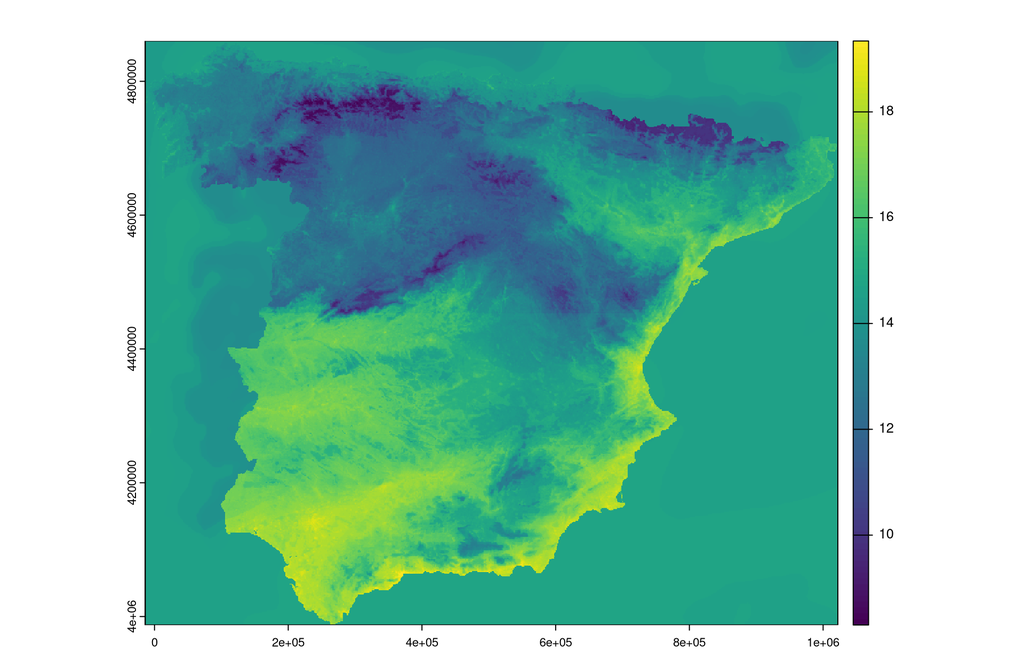

```r
prediction <- terra::predict(covariates, rfmodel)
plot(prediction)
```

## 5 Spatial cross-validation hyperparameter tuning

In many cases, the ideal model hyperparameters are not obvious and we have the possibility to tune them based on the data we have.

### 5.1 Define the c-v strategy and hyperparameters

Again, we first define the necessary **mlr3** objects for our tuning process. With `rsmp` we decide on a resampling strategy, i.e., the data partitions we use as cross-validation folds. The package **mlr3spatiotemporalcv** contains the popular spatial resampling strategies such as block CV (`spcv_block` used in the example below) or kNNDM.

For the `learner` instead of predefined hyperparameters, we use the function `to_tune()` where we can specify different values for the hyperparameters we want to test.

**Hide the code**

```r
library(mlr3spatiotempcv)

resampling_blockcv <- rsmp("spcv_block", folds = 5, range = 5000)

rfmodel <- lrn(
    "regr.ranger",
    num.trees = 100,
    mtry = to_tune(c(2, 4, 6, 10, 12)),
    min.node.size = to_tune(c(5, 10, 15)),
    importance = "impurity"
)
```

Now we can assemble everything together in a `tuning instance` object with the `ti()` function. The first four arguments should be self explanatory: `terminator` means, if we want to stop with our search for the best hyperparameter combination after some criteria is met. `store_benchmark_results` and `store_models` regulates whether we want to keep the measures and models for all the hyperparameter combinations we test.

Finally, we have to decide on a strategy on how to search with the `tuner` object. Here I use `grid_search` which is the brute force method that tests every possible combination once. We then execute the cross-validation with the `optimize` method from the `tuner` object.

**Hide the code**

```r
tuning_blockcv <- ti(
    task = task_spain, # the data
    resampling = resampling_blockcv, # the folds
    learner = rfmodel, # the rfmodel with mtry and min.node.size to tune
    measures = measure_rmse, # how to measure performance
    terminator = trm("none"),
    store_benchmark_result = TRUE,
    store_models = TRUE
)

tuner_grid_search <- mlr3tuning::tnr("grid_search")

tuner_grid_search$optimize(tuning_blockcv)
```

```
   min.node.size   mtry learner_param_vals  x_domain regr.rmse
          <char> <char>             <list>    <list>     <num>
1:            15     12          <list[5]> <list[2]> 0.8520169
```

The results are stored in the defined `tuning instance` object. We also have some nice plotting options with the **mlr3viz** package.

**Hide the code**

```r
tuning_blockcv$result_learner_param_vals
```

```
$importance
[1] "impurity"

$num.threads
[1] 1

$num.trees
[1] 100

$min.node.size
[1] 15

$mtry
[1] 12
```

**Hide the code**

```r
tuning_blockcv$result_y
```

```
regr.rmse
0.8520169
```

**Hide the code**

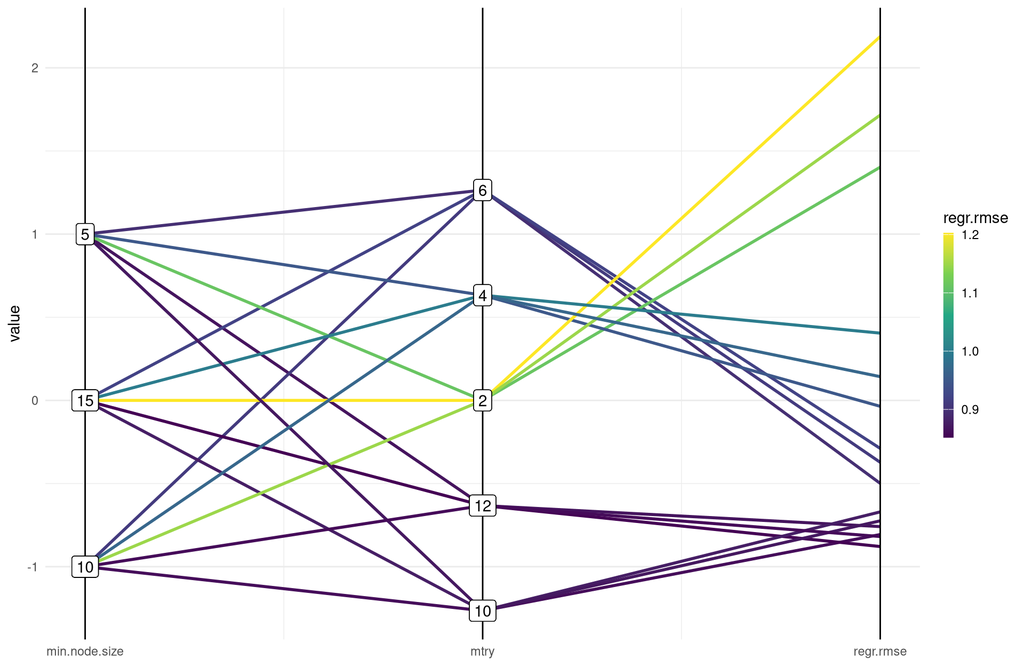

```r
autoplot(tuning_blockcv, type = "parallel")
```

Because we set `store_benchmark_result = TRUE` and `store_models = TRUE`, we also have a `archive` where all the other results are stored.

**Tuning Archive**

**Hide the code**

```r
tuning_blockcv$archive$data
```

```
    min.node.size   mtry regr.rmse warnings errors runtime_learners
           <char> <char>     <num>    <int>  <int>            <num>
 1:             5     12 0.8657247        0      0            0.153
 2:            10      6 0.9098643        0      0            0.106
 3:             5      6 0.8953927        0      0            0.111
 4:            15      6 0.9194065        0      0            0.076
 5:             5      2 1.1126819        0      0            0.075
 6:            10     10 0.8602758        0      0            0.111
 7:             5      4 0.9483508        0      0            0.087
 8:            15      2 1.2024457        0      0            0.055
 9:            15     12 0.8520169        0      0            0.103
10:            15     10 0.8758340        0      0            0.115
11:            10      2 1.1484717        0      0            0.064
12:            15      4 0.9986427        0      0            0.071
13:             5     10 0.8696826        0      0            0.139
```

[output cut: 19 more lines]

### 5.2 Final model with optimized hyperparameter

Once we found the optimal hyperparameter combination we can use them to train a final model on all the data. We define a new `learner` and assign the parameters from our `tuning instance` to it. Then we can train and predict again.

**Hide the code**

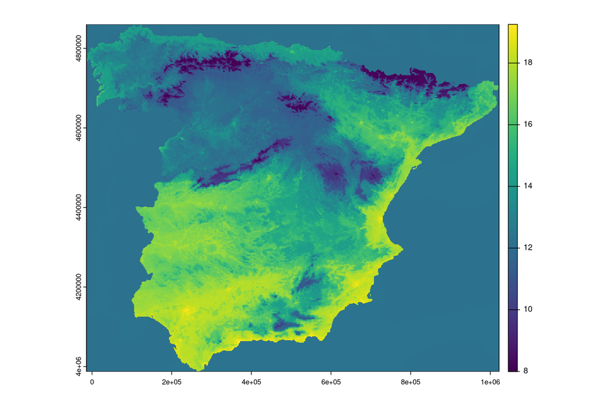

```r
tuned_rfmodel <- lrn("regr.ranger")
tuned_rfmodel$param_set$values <- tuning_blockcv$result_learner_param_vals

tuned_rfmodel$train(task_spain)
tuned_prediction <- terra::predict(covariates, tuned_rfmodel)
plot(tuned_prediction)
```

## 6 Feature Selection

### 6.1 Define the feature selection strategy

Similar to the hyperparameter tuning, we can use the cross-validation strategy to test whether we can build a model with reduces predictors / covariates / features / variable. Here I demonstrate a forward variable selection, that starts out with the best performing pair of variables and appends additional variables, if there is still an increase in our cross-validation performance estimation.

First we have to define the feature selection strategy with `fs()`. I use a learner here with fixed hyperparameters. Everything is put together in the `fselect()` function that creates a feature selection `instance` in which all the information, methods and results are stored.

**Hide the code**

```r
library(mlr3fselect)
library(mlr3filters)

select_mode <- fs("sequential", min_features = 2)

fs_rfmodel <- lrn(
    "regr.ranger",
    num.trees = 50,
    mtry = 2,
    min.node.size = 5,
    importance = "impurity"
)

set.seed(20)
feature_selection <- fselect(
    fselector = select_mode,
    task = task_spain,
    learner = fs_rfmodel,
    resampling = resampling_blockcv,
    measure = measure_rmse
)
```

**Hide the code**

```r
# selected variables
feature_selection$result_feature_set
```

```
[1] "Y"         "dem"       "lst_day"   "lst_night" "ntl"       "popdens"
```

**Hide the code**

```r
# CV RMSE with the selected variables
feature_selection$result$regr.rmse
```

```
[1] 0.7795219
```

### 6.2 Final model with selected features

Once we found the ideal combination of variables, we can reduce our task to those predictors, train a model and predict.

**Hide the code**

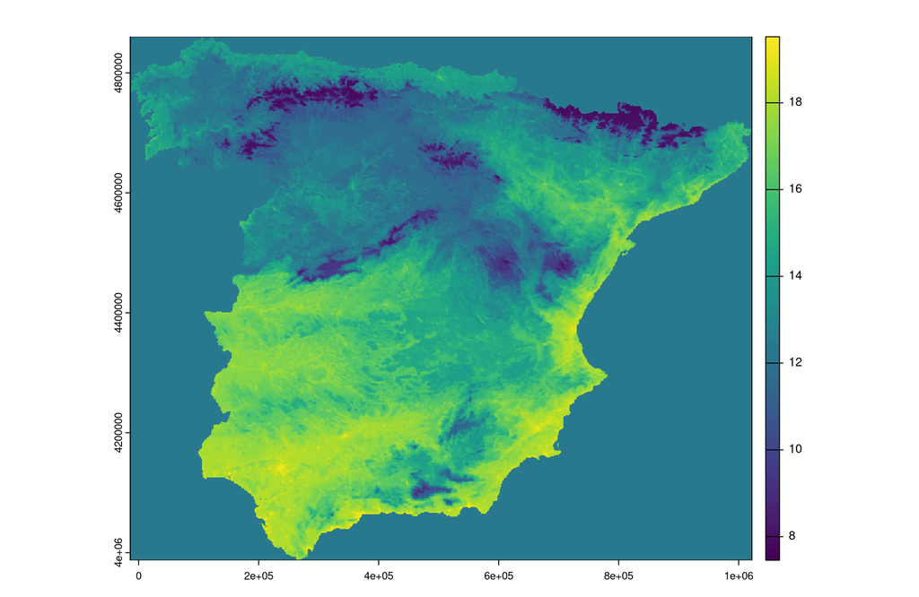

```r
fs_task <- task_spain$select(feature_selection$result_feature_set)

fs_rfmodel$train(fs_task)

fs_prediction <- terra::predict(covariates, fs_rfmodel)
plot(fs_prediction)
```

## 7 Conclusions

- Utilizes an **object-oriented approach** with `R6` classes, offering flexibility but requiring familiarity with this system in R.
- Possible target audience: **machine learning experts** and **Python users** transitioning to R, especially those familiar with object-oriented programming.

### 7.1 Strengths

- **Spatially explicit methods are directly implemented**: there is no need to exclude the geometry column of the `sf` object, allowing for the retention of spatial information.
- **Active development**: continuously updated with improvements and bug fixes.
- **Very good introduction to the framework through the book**: The book offers a well-structured guide for learning the **mlr3** framework.
- **Well-documented functions**: Clear and comprehensive documentation helps users understand the functions easily.

### 7.2 Weaknesses

- **Steep learning curve**: The framework’s complexity can be challenging for beginners.
- **Overwhelming number of methods and options**: The extensive methods can be difficult to navigate for new users.
- **Confusing help pages due to `R6` logic**: Understanding the `R6` logic in help files can be tough for those unfamiliar with the system.
- **No in-Line help in RStudio**: Lack of in-line help for `R6` methods in RStudio makes it harder to access function details quickly.